# Bibliometrix - RSL Eventos Climáticos Extremos

- **Preparando ambiente** Para essa análise será utilizada a biblioteca Bibliometrix e suas dependências, para instalar utilize o comando

```r
install.packages("bibliometrix", dependencies=TRUE)
```

- **Preparando a amostra**
- A exportação de conteúdo na Web Of Science é limitado a 500 registros, nesse estudo a amostra resultou em 572 documentos (12/jul/2022). Para que seja considerada a amostra toda, é necessário unir os arquivos

```r
library(bibliometrix)

file <- c("https://raw.githubusercontent.com/jairoalmeid/Bibliometrix/main/WebOfScience_export_part1.bib", "https://raw.githubusercontent.com/jairoalmeid/Bibliometrix/main/WebOfScience_export_part2.bib")

Amostra <- convert2df(file, dbsource = "wos", format = "bibtex")
```

```
Converting your wos collection into a bibliographic dataframe

Done!


Generating affiliation field tag AU_UN from C1:  Done!
```

- dbsource “isi” ou “wos” para arquivos vindo do Web Of Science; “scopus” para arquivos da base de dados Scopus; “pubmed” para arquivos da base PubMed;
- formart “bibtex” para arquivos em formato .bib “plaintext” para arquivos em formato .txt “endnote” para arquivos em formato .ciw
- ** Análise da importação **

Criação do objeto bibliometrix O objeto contem informações como número de documentos, distribuição e frequência por autores, Ano de publicação etc. Essas informações serão utilizadas para realizar a análise estatística da amostra.

```r
results <- biblioAnalysis(Amostra, sep = ";")
```

A descrição estatística pode ser feita através da impressão do sumário, que contém um resumo com algumas informações. Nesse caso a variável “k” delimita a quantidade de informações.

```r
options(width=100)
S <- summary(object = results, k = 5, pause = FALSE)
```

[output not shown]

| Year | Articles |
| --- | --- |
| 1994 | 1 |
| 1995 | 1 |
| 1997 | 1 |
| 1998 | 2 |
| 1999 | 4 |
| 2000 | 1 |
| 2001 | 2 |
| 2002 | 4 |
| 2003 | 5 |
| 2005 | 5 |

[output cut: 17 more lines]

```
Annual Percentage Growth Rate 14.08182


Most Productive Authors
```

|  | Authors | Articles | Authors | Articles Fractionalized |
| --- | --- | --- | --- | --- |
| 1 | WAMSLER C | 9 | WAMSLER C | 5.67 |
| 2 | WANG Z | 9 | ORHAN E | 3.00 |
| 3 | LI Y | 8 | CHEN X | 2.12 |
| 4 | LI X | 7 | PARTHASARATHY D | 2.00 |
| 5 | CHEN X | 6 | SUN KZ | 2.00 |

```
Top manuscripts per citations
```

|  | Paper | DOI | TC | TCperYear | NTC |
| --- | --- | --- | --- | --- | --- |
| 1 | GROEGER G, 2012, ISPRS-J PHOTOGRAMM REMOTE SENS | 10.1016/j.isprsjprs.2012.04.004 | 307 | 27.9 | 15.24 |
| 2 | DE SHERBININ A, 2007, ENVIRON URBAN | 10.1177/0956247807076725 | 237 | 14.8 | 5.46 |
| 3 | DESOUZA KC, 2013, CITIES | 10.1016/j.cities.2013.06.003 | 212 | 21.2 | 7.85 |
| 4 | VALE LJ, 2014, BUILD RES INFORMAT | 10.1080/09613218.2014.850602 | 179 | 19.9 | 8.28 |
| 5 | BERKE PR, 2006, ANN AM ACAD POLIT SOC SCI | 10.1177/0002716205285533 | 172 | 10.1 | 4.12 |

```
Corresponding Author's Countries
```

|  | Country | Articles | Freq | SCP | MCP | MCP_Ratio |
| --- | --- | --- | --- | --- | --- | --- |
| 1 | CHINA | 151 | 0.2649 | 124 | 27 | 0.179 |
| 2 | USA | 55 | 0.0965 | 47 | 8 | 0.145 |
| 3 | JAPAN | 33 | 0.0579 | 25 | 8 | 0.242 |
| 4 | INDIA | 32 | 0.0561 | 32 | 0 | 0.000 |
| 5 | TURKEY | 28 | 0.0491 | 28 | 0 | 0.000 |

```
SCP: Single Country Publications

MCP: Multiple Country Publications


Total Citations per Country
```

|  | Country | Total Citations | Average Article Citations |
| --- | --- | --- | --- |
| 1 | USA | 1627 | 29.582 |
| 2 | CHINA | 1162 | 7.695 |
| 3 | GERMANY | 798 | 33.250 |
| 4 | SWEDEN | 349 | 38.778 |
| 5 | UNITED KINGDOM | 343 | 18.053 |

```
Most Relevant Sources
```

|  | Sources | Articles |
| --- | --- | --- |
| 1 | INTERNATIONAL JOURNAL OF DISASTER RISK REDUCTION | 25 |
| 2 | REMOTE SENSING | 20 |
| 3 | SUSTAINABILITY | 19 |
| 4 | NATURAL HAZARDS | 17 |
| 5 | CITIES | 8 |

```
Most Relevant Keywords
```

|  | Author Keywords (DE) | Articles | Keywords-Plus (ID) | Articles |
| --- | --- | --- | --- | --- |
| 1 | URBAN PLANNING | 97 | VULNERABILITY | 33 |
| 2 | RESILIENCE | 41 | FRAMEWORK | 28 |
| 3 | GIS | 35 | MODEL | 27 |
| 4 | CLIMATE CHANGE | 27 | CLIMATE-CHANGE | 24 |
| 5 | REMOTE SENSING | 27 | DISASTER | 22 |

```
NA
```

- ** Plotagem gráfica **

Após criar o objeto Bibliometrix, é possível fazer a plotagem gráfica dos resultados. A variável “k” determina a quantidade de elementos que serão plotados

[figure not shown]

[figure not shown]

[figure not shown]

[figure not shown]

[figure not shown]

```r
plot(x = results, k = 15, pause = FALSE)
```

- ** Análise de referências e citações ** A função citations gera uma tabela de frequências com os primeiros-autores mais citados

```r
# Análise de autores mais citados
CR <- localCitations(Amostra, sep = ";")
CR$Authors[1:10,]
```

|  | Author | LocalCitations |
| --- | --- | --- |
| 1397 | WAMSLER C | 13 |
| 326 | DESOUZA KC | 6 |
| 410 | FLANERY TH | 6 |
| 182 | BRINK E | 4 |
| 690 | KOC E | 4 |
| 1110 | RIVERA C | 4 |
| 1189 | SENGEZER B | 4 |
| 159 | BLACKBURN S | 3 |
| 630 | JOHNSON C | 3 |
| 1 | ABDOLLAHI A | 2 |

```r
# Análise dos papers mais citados
CR <- localCitations(Amostra, sep = ";")
CR$Papers[1:10,]
```

|  | Paper | DOI | Year | LCS | GCS |
| --- | --- | --- | --- | --- | --- |
| 113 | DESOUZA KC, 2013, CITIES | 10.1016/j.cities.2013.06.003 | 2013 | 6 | 212 |
| 25 | SENGEZER B, 2005, DISASTERS | 10.1111/j.0361-3666.2005.00279.x | 2005 | 4 | 29 |
| 110 | WAMSLER C, 2013, J CLEAN PROD | 10.1016/j.jclepro.2012.12.008 | 2013 | 4 | 149 |
| 27 | WAMSLER C, 2006, DISASTERS | 10.1111/j.0361-3666.2006.00313.x | 2006 | 3 | 61 |
| 131 | JOHNSON C, 2014, ENVIRON URBAN | 10.1177/0956247813518684 | 2014 | 3 | 48 |
| 165 | WAMSLER C, 2015, ECOL SOC | 10.5751/ES-07489-200230 | 2015 | 3 | 65 |
| 31 | WAMSLER C, 2006, OPEN HOUSE INT |  | 2006 | 2 | 3 |
| 55 | EBERT A, 2009, NAT HAZARDS | 10.1007/s11069-008-9264-0 | 2009 | 2 | 99 |
| 305 | PARK KY, 2018, DESALIN WATER TREAT | 10.5004/dwt.2018.22154 | 2018 | 2 | 6 |
| 434 | ABDOLLAHI A, 2020, IEEE ACCESS | 10.1109/ACCESS.2020.3038225 | 2020 | 2 | 18 |

- ** Índice de dominância **

Criado por Kumar, S., & Kumar, S. (2008) calcula o ranking de dominância dos autores

```r
DF <- dominance(results, k = 10)
DF
```

|  | Author | Dominance Factor | Tot Articles | Single-Authored | Multi-Authored | First-Authored | Rank by Articles | Rank by DF |
| --- | --- | --- | --- | --- | --- | --- | --- | --- |
| 1 | CHEN J | 0.4000000 | 5 | 0 | 5 | 2 | 5 | 1 |
| 2 | WAMSLER C | 0.3333333 | 9 | 3 | 6 | 2 | 1 | 2 |
| 3 | ZHANG Y | 0.3333333 | 6 | 0 | 6 | 2 | 4 | 2 |
| 4 | CHEN W | 0.3333333 | 3 | 0 | 3 | 1 | 9 | 2 |
| 5 | HUANG X | 0.3333333 | 3 | 0 | 3 | 1 | 9 | 2 |
| 6 | HU J | 0.2500000 | 4 | 0 | 4 | 1 | 7 | 6 |
| 7 | WANG Y | 0.2500000 | 4 | 0 | 4 | 1 | 7 | 6 |
| 8 | WANG Z | 0.2222222 | 9 | 0 | 9 | 2 | 1 | 8 |
| 9 | ZHANG J | 0.2000000 | 5 | 0 | 5 | 1 | 5 | 9 |
| 10 | LI X | 0.1428571 | 7 | 0 | 7 | 1 | 3 | 10 |

- ** Autor h-index **

```r
authors=gsub(","," ",names(results$Authors)[1:10])

indices <- Hindex(Amostra, field = "author", elements=authors, sep = ";", years = 50)

indices$H
```

| Element | h_index | g_index | m_index | TC | NP | PY_start |
| --- | --- | --- | --- | --- | --- | --- |
| CHEN J | 1 | 2 | 0.5000000 | 4 | 2 | 2021 |
| CHEN X | 3 | 4 | 0.5000000 | 28 | 4 | 2017 |
| LI X | 3 | 6 | 0.5000000 | 155 | 6 | 2017 |
| LI Y | 3 | 6 | NA | 65 | 6 | NA |
| LIU X | 2 | 3 | 0.1428571 | 135 | 3 | 2009 |
| LIU Y | 3 | 3 | 0.7500000 | 102 | 3 | 2019 |
| WAMSLER C | 7 | 9 | 0.4117647 | 372 | 9 | 2006 |
| WANG B | 3 | 3 | 0.3333333 | 76 | 3 | 2014 |
| WANG Z | 3 | 4 | 0.7500000 | 39 | 4 | 2019 |
| ZHANG Y | 4 | 4 | 0.6666667 | 181 | 4 | 2017 |

[figure not shown]

```r
# Lista o autor com maior produtividade ao longo do tempo
topAU <- authorProdOverTime(Amostra, k = 15, graph = TRUE)
```

```r
head(topAU$dfAU)
```

|  | Author | year | freq | TC | TCpY |
| --- | --- | --- | --- | --- | --- |
| 1 | CHEN J | 2010 | 1 | 0 | 0.0 |
| 2 | CHEN J | 2014 | 1 | 0 | 0.0 |
| 3 | CHEN J | 2021 | 1 | 1 | 0.5 |
| 4 | CHEN J | 2022 | 2 | 3 | 3.0 |
| 5 | CHEN X | 2014 | 1 | 0 | 0.0 |
| 6 | CHEN X | 2017 | 2 | 6 | 1.0 |

- ** Coeficiente de Lotka **

A lei de Lotka descreve a frequência de publicação por autor. Segundo essa lei o número de autores que publicam um determinado número de artigos é uma proporção fixa para o número de autores que publicam um único artigo.

```r
L <- lotka(results)
L$AuthorProd
```

| N.Articles | N.Authors | Freq |
| --- | --- | --- |
| 1 | 1482 | 0.9131238447 |
| 2 | 95 | 0.0585335798 |
| 3 | 29 | 0.0178681454 |
| 4 | 6 | 0.0036968577 |
| 5 | 3 | 0.0018484288 |
| 6 | 4 | 0.0024645718 |
| 7 | 1 | 0.0006161429 |
| 8 | 1 | 0.0006161429 |
| 9 | 2 | 0.0012322859 |

```r
# Coeficiente estimado
L$Beta
```

```
[1] 3.287741
```

```r
# Plot com índice esperado e observado, seguindo a lei de Lotka

Observed=L$AuthorProd[,3]
Theoretical=10^(log10(L$C)-2*log10(L$AuthorProd[,1]))

plot(L$AuthorProd[,1],Theoretical,type="l",col="red",ylim=c(0, 1), xlab="Artigos",ylab="Freq. por autores",main="Produção Científica")
lines(L$AuthorProd[,1],Observed,col="blue")
```

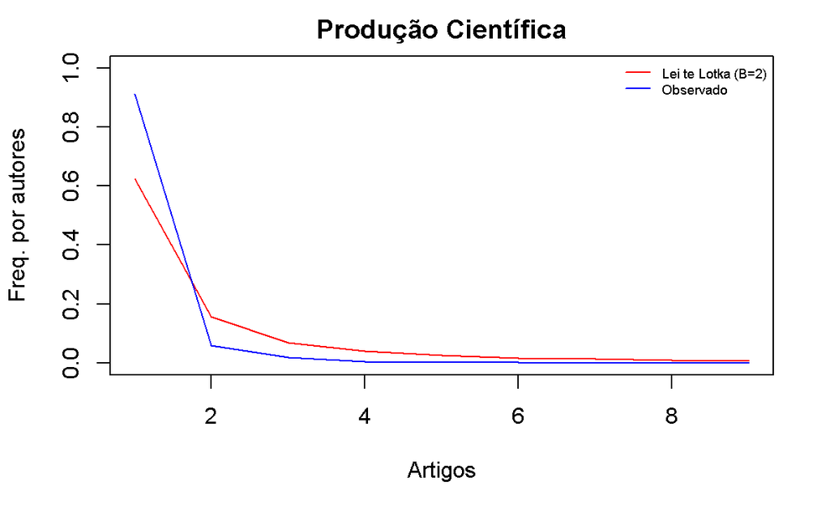

```r
legend(x="topright",c("Lei te Lotka (B=2)","Observado"),col=c("red","blue"),lty = c(1,1,1),cex=0.6,bty="n")
```

**Conexão entre artigos** Os artigos podem apresentar conexões entre si, essa análise é feita através da relação entre autores, keywords

```r
# Relação de artigos por revistas
A <- cocMatrix(Amostra, Field = "SO", sep = ";")
sort(Matrix::colSums(A), decreasing = TRUE)[1:10]
```

```
                                INTERNATIONAL JOURNAL OF DISASTER RISK REDUCTION
                                                                              25
                                                                  REMOTE SENSING
                                                                              20
                                                                  SUSTAINABILITY
                                                                              19
                                                                 NATURAL HAZARDS
                                                                              17
                                                                          CITIES
                                                                               8
                                  ISPRS INTERNATIONAL JOURNAL OF GEO-INFORMATION
                                                                               8
IEEE JOURNAL OF SELECTED TOPICS IN APPLIED EARTH OBSERVATIONS AND REMOTE SENSING
                                                                               7
                                                                       DISASTERS
                                                                               6
                                                  SUSTAINABLE CITIES AND SOCIETY
                                                                               6
                                                    ENVIRONMENT AND URBANIZATION
                                                                               5
```

```r
 A <- cocMatrix(Amostra, Field = "AU", sep = ";")
sort(Matrix::colSums(A), decreasing = TRUE)[1:10]
```

```
WAMSLER C    WANG Z      LI Y      LI X    CHEN X     LIU X   ZHANG Y
        9         9         8         7         6         6         6
   CHEN J    WANG B   ZHANG J
        5         5         5
```

**Colaboração Científica Internacional** Analisa a conexão entre os países para colaboração científica das produções

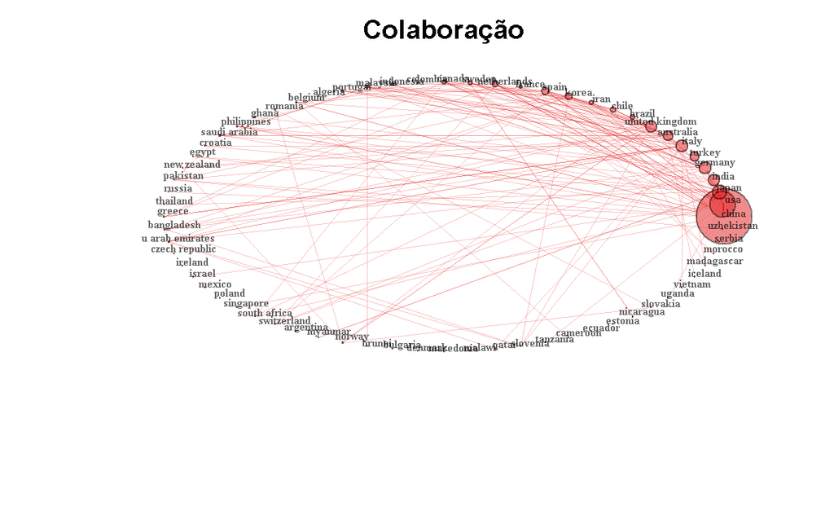

```r
M <- metaTagExtraction(Amostra, Field = "AU_CO", sep = ";")
NetMatrix <- biblioNetwork(M, analysis = "collaboration", network = "countries", sep = ";")

net=networkPlot(NetMatrix, n = dim(NetMatrix)[1], Title = "Colaboração", type = "circle", size=TRUE, remove.multiple=FALSE,labelsize=0.5,cluster="none")
```

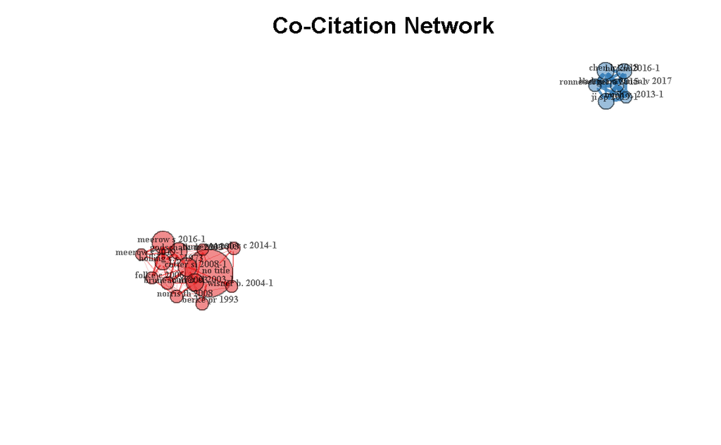

```r
# Create a co-citation network

NetMatrix <- biblioNetwork(Amostra, analysis = "co-citation", network = "references", sep = ";")

# Plot the network
net=networkPlot(NetMatrix, n = 20, Title = "Co-Citation Network", type = "fruchterman", size=T, remove.multiple=FALSE, labelsize=0.5,edgesize = 5)
```

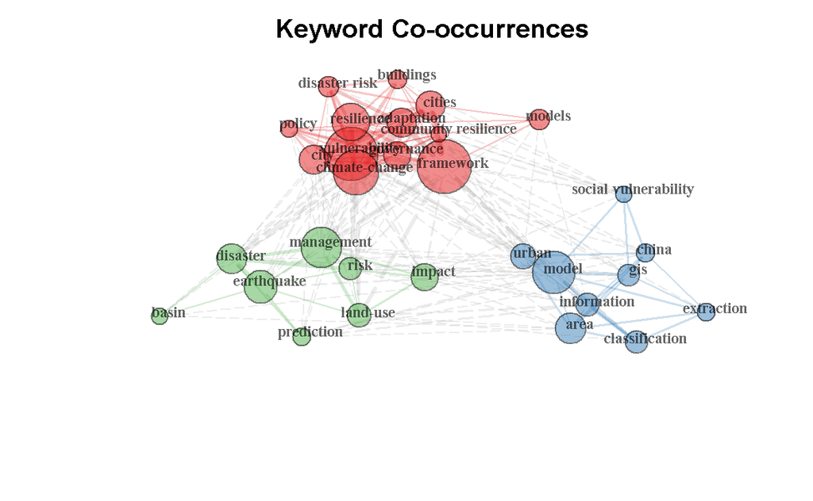

```r
# Create keyword co-occurrences network

NetMatrix <- biblioNetwork(Amostra, analysis = "co-occurrences", network = "keywords", sep = ";")

# Plot the network
net=networkPlot(NetMatrix, normalize="association", weighted=T, n = 30, Title = "Keyword Co-occurrences", type = "fruchterman", size=T,edgesize = 5,labelsize=0.7)
```

[figure not shown]

[figure not shown]

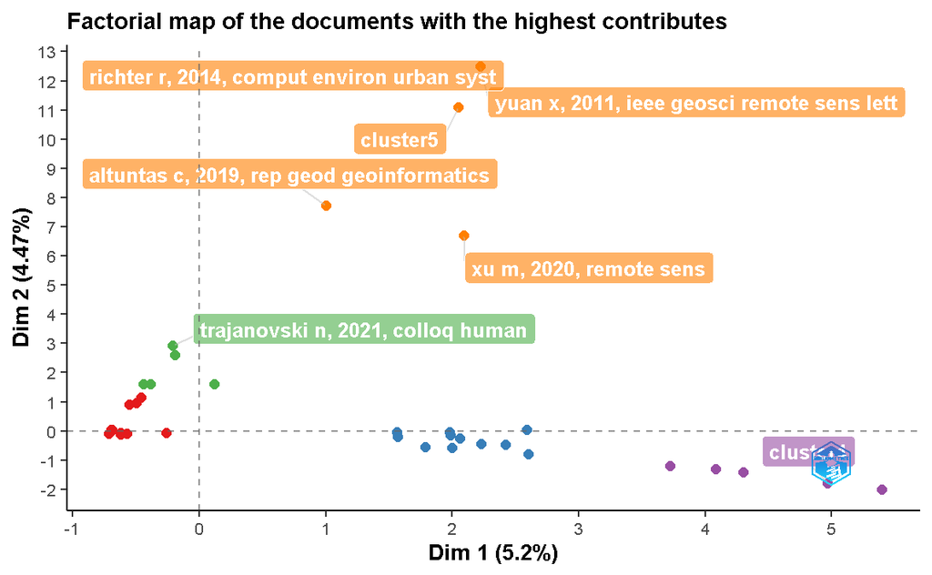

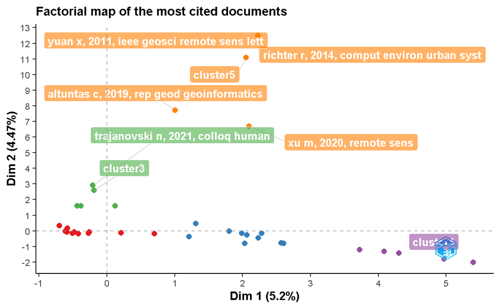

```r
CS <- conceptualStructure(Amostra,field="ID", method="CA", minDegree=4, clust=5, stemming=FALSE, labelsize=10, documents=10)
```